# Percentiles and Boxplots

P. Lombardo

## Loading packages and data

```r
library(tidyverse)
small_diamonds <-read.csv("data/small_diamonds.csv", header = T,
                          stringsAsFactors = T)
diamond_compare <-read.csv('data/diamond_compare.csv',
                           header =T, stringsAsFactors = T)
source('source_files/general.R')
```

# Our data today

The `diamonds` data set comes pre-loaded with the `ggplot2` library, but it is quite large. To simplify a little, we will work with 400 randomly sampled diamonds from that data set; we store this information in the `small_diamonds` data frame.

Let’s explore

```r
small_diamonds %>% head()
```

```
##   carat       cut color clarity depth table price    x    y    z
## 1  1.21     Ideal     G     VS2  61.2    57  7792 6.90 6.85 4.21
## 2  0.40     Ideal     D     SI1  62.1    56   772 4.70 4.74 2.93
## 3  1.09   Premium     F     VS1  61.3    60  7588 6.67 6.61 4.07
## 4  0.83 Very Good     E     SI2  58.0    62  2799 6.19 6.25 3.61
## 5  0.83      Fair     H     SI2  65.1    59  2133 5.84 5.81 3.79
## 6  0.41     Ideal     E     SI1  62.5    55   969 4.77 4.73 2.97
```

```r
small_diamonds %>% str()
```

```
## 'data.frame':    400 obs. of  10 variables:
##  $ carat  : num  1.21 0.4 1.09 0.83 0.83 0.41 0.31 0.9 0.33 0.41 ...
##  $ cut    : Factor w/ 5 levels "Fair","Good",..: 3 3 4 5 1 3 3 4 2 4 ...
##  $ color  : Factor w/ 7 levels "D","E","F","G",..: 4 1 3 2 5 2 2 3 2 2 ...
##  $ clarity: Factor w/ 8 levels "I1","IF","SI1",..: 6 3 5 4 4 3 3 4 3 8 ...
##  $ depth  : num  61.2 62.1 61.3 58 65.1 62.5 60.1 62.3 63.4 60.9 ...
##  $ table  : num  57 56 60 62 59 55 57 57 55 60 ...
##  $ price  : int  7792 772 7588 2799 2133 969 601 3704 579 1243 ...
##  $ x      : num  6.9 4.7 6.67 6.19 5.84 4.77 4.36 6.18 4.37 4.82 ...
##  $ y      : num  6.85 4.74 6.61 6.25 5.81 4.73 4.39 6.15 4.4 4.81 ...
##  $ z      : num  4.21 2.93 4.07 3.61 3.79 2.97 2.63 3.84 2.78 2.93 ...
```

For data sets and functions that come pre-loaded into `R`, you can use a `?` to learn more about them.

```r
?diamonds
```

### Removing columns

For this session, we will focus on just a small subset of the variables in `small_diamonds`. The `select()` function from the `dplyr` package allows us to *select* a subset of columns from a larger data frame.

Let’s write some code together that creates a new data frame `diamonds2` that only contains the variables: `carat`, `cut`, `depth`, `price`.

```r
# First build the dplyr pipe and make sure you get the right data frame
diamonds2 <- small_diamonds %>%
    select(cut, carat, depth, price)
# Once you know your code is working, do an assignment to the shortcut name diamonds2.  You can do forward assignment -> or backward assignment <-.
```

## Percentiles

Rough guide, my exam grade was better than 72% of my classmates grades, I would say *I scored in the 72nd percentile*.

- Notice you do not need to know my actual grade to say this; it is simply a measure of where I stand among the other exam grades

Often we want to reverse this situation: how high do I need to score in order to beat 85% of my classmates? Said differently, *What is the 85th percentile score?*

### Logical vectors and percentiles

A logical vector is simply a vector of TRUE or FALSE values, but `R` uses them in a number of ways. In general, `R` will allow you to perform *quantitative* summaries on logical vectors, and it does this by treating:

- TRUE is the same as 1
- FALSE is the same as 0.

This has some fun implications! Yes, I really think this is fun… why do you ask?

Run the following code and think about what it does:

```r
# first create a simple vector of numbers:
numbers<- c(1, 2, 3, 4, 5, 6, 7)
numbers
```

```
## [1] 1 2 3 4 5 6 7
```

```r
# What does this code do?
numbers < 4
```

```
## [1]  TRUE  TRUE  TRUE FALSE FALSE FALSE FALSE
```

Now let’s see how `R` will treat this “logical vector”, `numbers < 4`, if we try to `sum()` it:

```r
sum(numbers<4)
```

```
## [1] 3
```

**Exercise:** What percentage of the diamond prices in `diamonds2` are above the mean price?

```r
# Here's a guide (not the only way though):

# Compute the mean, save it under mean_price
mean_price <- mean(diamonds2$price)

# Create a logical vector for price values above  mean_price

# diamonds2$price < mean_price

# Use the logical vector to find the total number of diamonds priced above the mean
sum(diamonds2$price < mean_price)
```

```
## [1] 251
```

```r
# take that total number and divide by the total rows in the data frame (nrow() helps)
sum(diamonds2$price < mean_price)/nrow(diamonds2)
```

```
## [1] 0.6275
```

The mean, 3655.418, is actually the 63rd percentile! Is that what we usually expect?

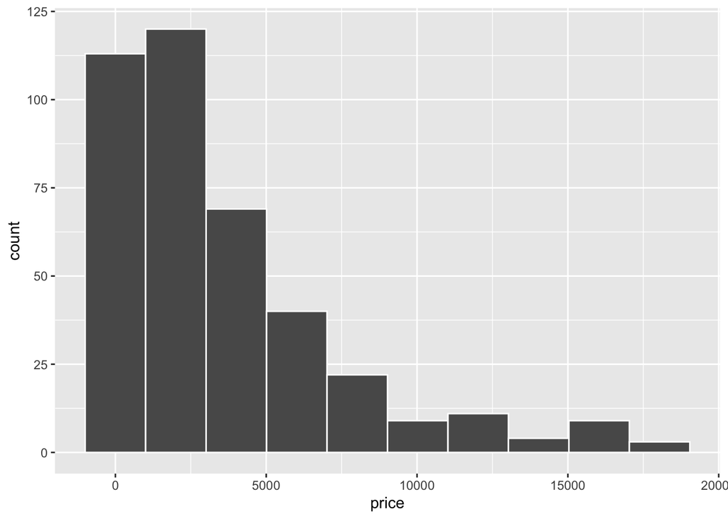

```r
ggplot(data = diamonds2,
       aes(x = price))+
    geom_histogram(color='white',
                   bins = 10)
```

Alternative approaches:

```r
# the mean of 0's and 1's is a percentage of 1's
mean(diamonds2$price < mean_price)
```

```
## [1] 0.6275
```

```r
# this is kind of ugly actually, but
# we haven't learned some stuff that would make
# this easier.
mean((diamonds2 %>% pull(price)) < mean_price)
```

```
## [1] 0.6275
```

## The harder direction

Suppose we are interested in the following question instead:

- What is the 80th percentile for the `carat` measurement?
- Said differently, how many carats would a diamond need to weight in order to be heavier than 80% of the other diamonds in the data set?

We rely on the `quantile()` command to find these quickly. To use this properly, you first put your data vector, then pass the percentile you want in next *as a decimal*. Let’s find the 80th percentile of the `carat` variable:

```r
#Place code here
quantile(diamonds2$carat, 0.8)
```

```
##  80%
## 1.09
```

Yes, we can use this as part of a `summarize()` table, so long as we only compute one percentile at a time. Try adding the 80th percentile to the table below.

```r
diamonds2 %>%
    summarise("mean (carat)" = mean(carat),
              std.dev = sd(carat),
              perc_80 = quantile(carat,.8))
```

```
##   mean (carat)   std.dev perc_80
## 1      0.76855 0.4583871    1.09
```

We can compute a bunch of percentiles at once by passing a vector of probabilities into the `probs =` argument. For example, try putting `c(.1, .25, .5, .75, .9)` into that argument:

```r
# Place code here.
quantile(diamonds2$carat, c(.1, .25, .5, .75, .9) )
```

```
##  10%  25%  50%  75%  90%
## 0.31 0.38 0.70 1.01 1.51
```

**Quartiles** are a fancy way of referring to the 25th, 50th, and 75th percentiles. Specifically,

- The first quartile $Q_1$ is the same as the 25th percentile $P_{25}$
- The second quartile $Q_2$ is the same as the 50th percentile $P_{50}$ (also the median)
- The third quartile $Q_3$ is the same as the 75th percentile $P_{75}$

```r
#  take your guess!
summary(diamonds$carat)
```

```
##    Min. 1st Qu.  Median    Mean 3rd Qu.    Max.
##  0.2000  0.4000  0.7000  0.7979  1.0400  5.0100
```

#### A new measure of variation

We define the *inter-quartile range* (IQR) to be the difference between the third and first quartiles: Q3 - Q1. The `IQR()` function computes this quickly in R.

```r
IQR(diamonds2$carat)
```

```
## [1] 0.63
```

The interquartile range is an important measure of variation for certain types of data. We’ll learn more the in exploration below!

A boxplot is a nice way of visualizing the min, Q1, Q2, Q3 and max of a data set.

- The lowest dot (or line) is the min,
- the start of the box is the first quartile
- the middle line of the box is the median
- the end of the box is the third quartile
- the highest dot (or line) is the max.

Here is a box plot for the carat measurement

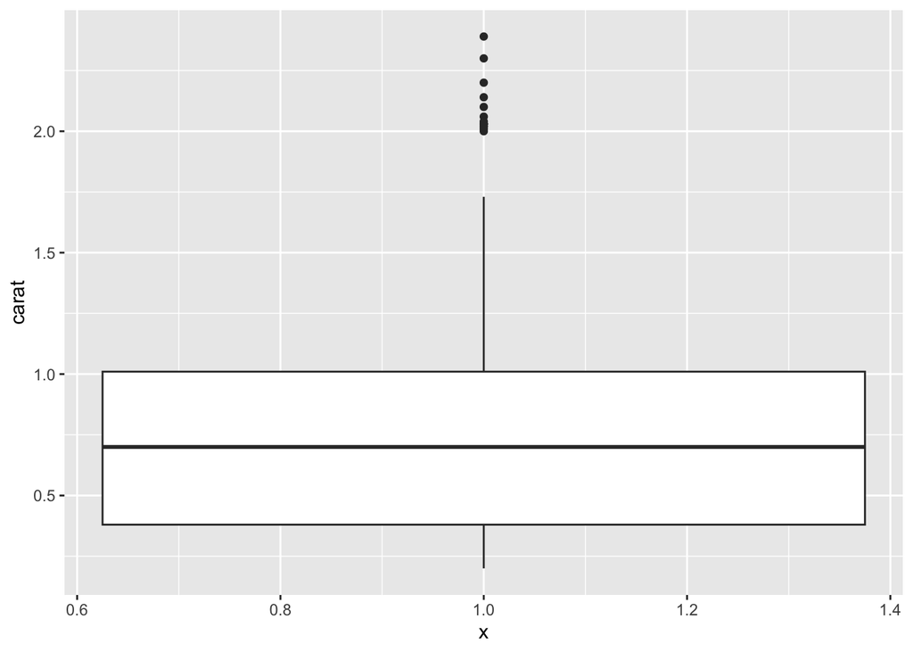

```r
ggplot(data = diamonds2,
       aes(x = 1, y = carat))+
    geom_boxplot()
```

Box plots are most useful when you compare them accross different groupings of your data. For example, here is code that would look at `carat` accross different `cut`s of diamonds. Notice the `x` aesthetic is now a grouping variable from the data frame.

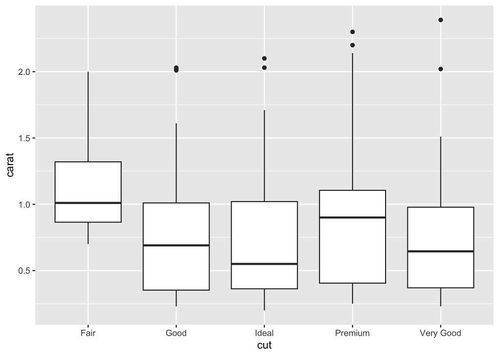

```r
ggplot(data = small_diamonds,
       aes(x = cut, y = carat))+
    geom_boxplot()
```

Here we see that diamonds with a Fair cut have the highest median (middle line of the box), and the least amount of variation as measured by the IQR (the box is shortest!).

## Why do we *care?*

Let’s compare two diamond collections. For a private collection, and for the Smithsonian collection, we randomly select 50 diamonds from each.

Run the code below to compare the mean and standard deviation of the carat measurement for each collection.

```r
diamond_compare %>%
    group_by(collection) %>%
    summarise(mean = mean(carat),
              std.dev = sd(carat),
              # add your median and IQR summaries...
              median = median(carat),
              IQR = IQR(carat)
              ) %>%
    # Remember you can only use flip_tibble() inside our lessons.
    flip_tibble()
```

```
## # A tibble: 4 × 3
##   name    Private Smithsonian
##   <chr>     <dbl>       <dbl>
## 1 mean      0.684       1.58
## 2 std.dev   0.513       6.36
## 3 median    0.41        0.41
## 4 IQR       0.585       0.665
```

Now, add median and IQR (our “percentile-based” measure of center and spread). What do you notice?

- The mean and standard deviation imply there is a big difference in the carat measurements between these two collections. However, the median and IQR, do not show the same big difference; they are pretty much the same.
- Median and IQR are not influenced by outliers, so this could be an indication that there are a few diamonds with either really large carat measurement or really small carat measurements that are influecing the mean and standard deviation to make the collection look different.

## Boxplots

Let’s try to visualize the difference we are observing above. One common visual that relies on “percentile” measurements is a boxplot.

To make a boxplot in ggplot, we assign one axis aesthetic to the grouping variable (usually `x`), and the other to the quantitative variable (usually `y`). Then, we simply use the geometry `geom_boxplot()`. Try it below!

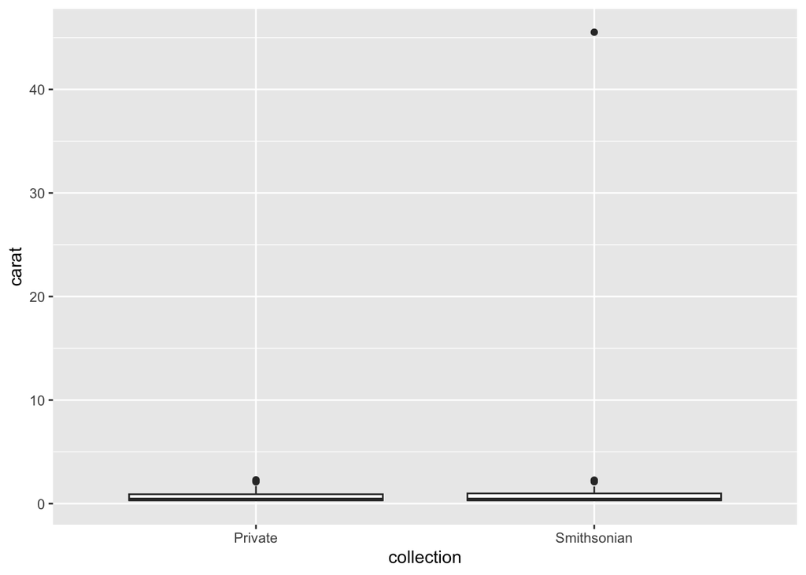

```r
# Try to write you code from scratch!
ggplot(data = diamond_compare,
       aes(x = collection,
           y = carat))+
    geom_boxplot()
```

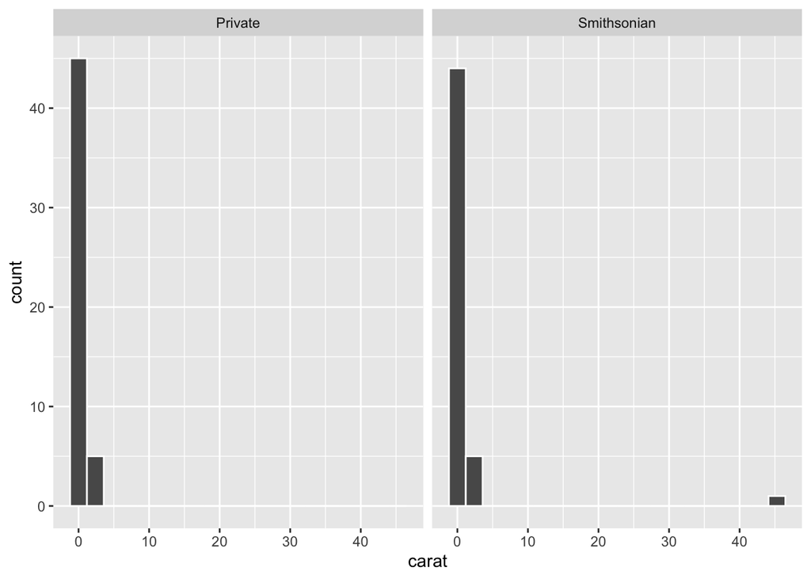

```r
ggplot(data = diamond_compare,
       aes( x = carat))+
    geom_histogram(bins = 20, color='white') +
    facet_wrap(vars(collection))
```

Yikes! Our boxplot got smushed, but at least we are starting to see what the issue might be….

**Exercise**. How many diamonds weigh more than 2.5 carats?

```r
# nice review, can you write the code?
sum(diamond_compare$carat > 2.5)
```

```
## [1] 1
```

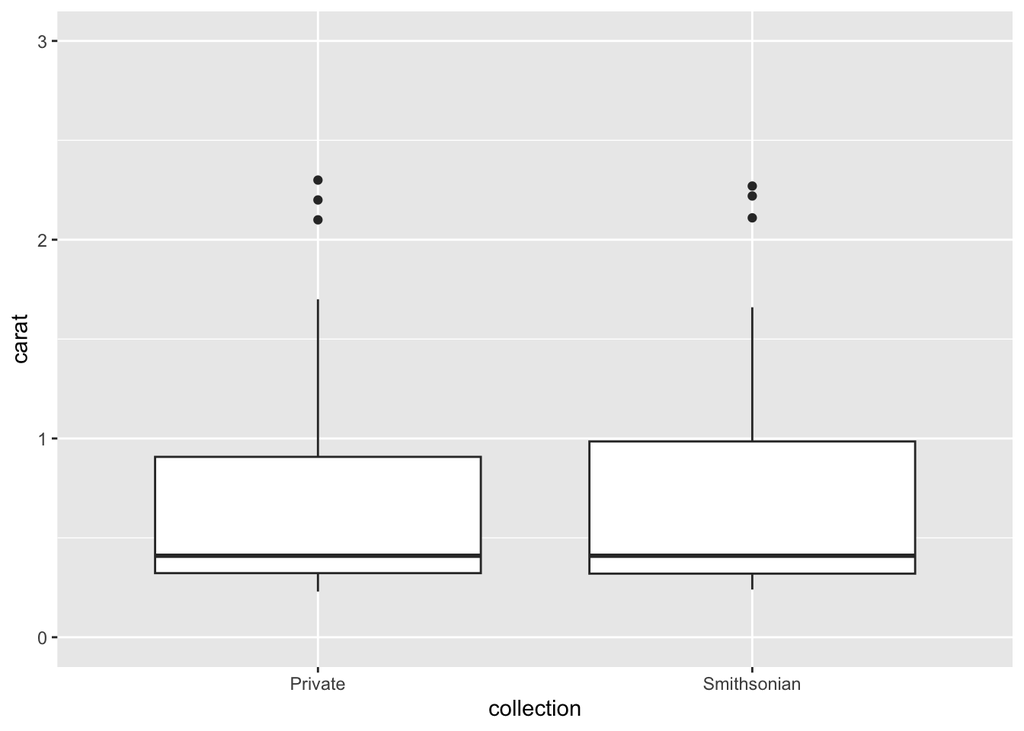

```r
ggplot(data = diamond_compare,
       aes(x = collection,
           y = carat))+
    geom_boxplot()+
    coord_cartesian(ylim=c(0,3))
```

### Challenges!

**Exercise**: Can you create histograms for each in a single plot?

*We did this above with `facet_wrap()`.*

```r
# write your code here...
ggplot(data = diamond_compare,
       aes( x = carat))+
    geom_histogram(bins = 20, color='white') +
    facet_wrap(vars(collection))
```

[output not shown]

Yikes, weird looking histograms.

**Exercise**. Try making the following modifications (yes, I had to play around to get this just right):

- use `bins = 200` and `color="white"` inside the histogram geometry
- add the layer `coord_cartesian(xlim=c(0,3))`. (Notice `xlim` and not `ylim` here…)

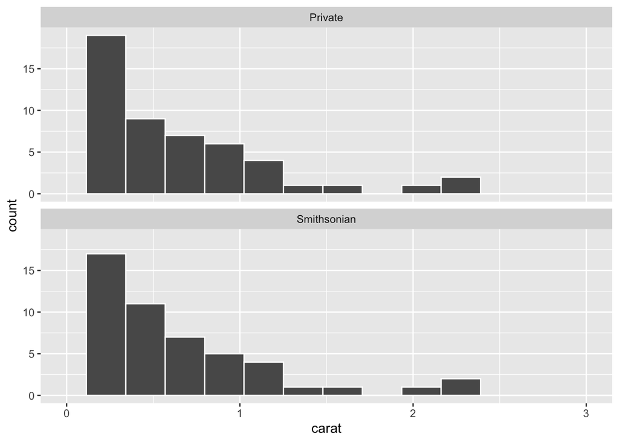

```r
# copy and paste your code above, add the coord_cartesian() layer
ggplot(data = diamond_compare,
       aes(x = carat))+
    geom_histogram(bins = 200,color="white")+
    facet_wrap(vars(collection), nrow=2)+
    coord_cartesian(xlim=c(0,3))
```

**Exercise.** How much does the “outlier” diamond weigh?

```r
# Place your code here.
max(diamond_compare$carat)
```

```
## [1] 45.52
```

### Final thoughts

So what’s going on with the sample from the Smithsonian collection? I *hope* you figure it out.